# Relationship Between Weekly Wages and Age in the World’s Most Valuable Football Team Leagues

Andrew Geha

## Introduction

It is no secret that spending in the world’s top footballing leagues–such as the English Premier League and Spain’s La Liga–has recently skyrocketed. For example, the French team Paris Saint-German F.C. paid a record fee of around 193.5 million British Pounds (222 million Euros) for F.C. Barcelona’s Neymar Jr. In 2016, Manchester United paid 91.5 million pounds for Paul Pogba. I observed the weekly wages for the world’s top 5 most valuable teams–Real Madrid, Manchester United, Barcelona, Bayern Munich, and Arsenal–to see if players’ weekly wages were correlated with age. I hypothesized that 1) age would be positively correlated with weekly wages, particularly in the most valuable English Premier League (EPL) teams, that 2) younger players (ages 18-24) in the La Liga teams make more than young players in the other teams, and that 3) the Bundesliga’s Bayern Munich would show the least growth between weekly wages and age.

Hypothesis 1 is based on the high spending trends of the EPL. Added to the expensive transfer of Paul Pogba, Manchester United also recently paid 75 million pounds and Arsenal paid 55 million pounds for Pierre-Emerick Aubameyang. As the players grow and if the teams will want to keep hold of them with new contracts, their already high fees will only grow higher.

Hypothesis 2 is based on the fact that since 2010, Real Madrid and Barcelona have won a combined 5 UEFA Champions League finals. Knowing this, I would think that those two teams would be most likely to invest in dynamic youth players.

Relative to the other footbal leagues, German football teams tend to spend less on players, which is the logic from which I constructed Hypothesis 3.

I will refer to each team as the league to which they belong, although it is important to note that although I will call Bayern Munich “the Bundesliga” in the following analyses, Bayern is the sole Bundesliga team in the top 5 most valuable team list.

## Data Dictionary

Here is a data dictionary for the wage_age dataset: -**weekly_wages**: A numeric variable describing the weekly wages of each player, in British Pounds Sterling. -**league**: A categorical variable describing the league to which the respective player belongs to. Possible options are: “La Liga” (Spanish Professional Football League) “EPL” (English Premier League) “Bundesliga” (German Professional Football League) -**age**: The age of each respective player.

Which can be be read in as:

```
##     age     league weekly_wages
## 1    30    La Liga        85000
## 2    30    La Liga        30000
## 3    31    La Liga       200000
## 4    24    La Liga       100000
## 5    27    La Liga        70000
## 6    29    La Liga       100000
## 7    25    La Liga        85000
## 8    23    La Liga        75000
## 9    25    La Liga        90000
## 10   27    La Liga       200000
## 11   31    La Liga       180000
## 12   21    La Liga        20000
## 13   25    La Liga        70000
## 14   21    La Liga        75000
```

[output cut: 107 more lines]

## Methods

I collected the information for my dataset from the following websites: totalsportek.com, spotrac.com, and tsmsportz.com, as well as through basic Google searches. From the websites, I attained the 2017/18 weekly wages for each of the top 5 most valuable teams in the world. I listed each player’s age, the league to which they belong, and their weekly wages in British Pounds-Sterling. Each row in the dataset represents a player from each team, in the order of the teams’ rankings in value.

To test Hypothesis 1, I used a regression model to test weekly wages as a function of player age. I also then filtered out the players in the EPL teams into a separate dataset to see if any significance I found in the overall sample still held between just Manchester United and Arsenal.

Next, in order to test Hypothesis 2, I filtered out the players aged 24 and under from the overall dataset. I created La Liga as the baseline in the regression model for that hypothesis, where tested weekly wages as a function of each league. La Liga as the baseline allowed me to see if the other 2 leagues in question differed significantly from the Spanish squads.

## Results

The mean weekly wages across all top 5 most valuable teams is calculated below, at around £98,706.61.

```
## [1] 98706.61
```

The distribution for weekly wages for each league is shown below, to give an idea of the amount of money being spent by the respective teams on their players. For each league, most of the players are within receiving between £50,000 and around £100,000 a week.

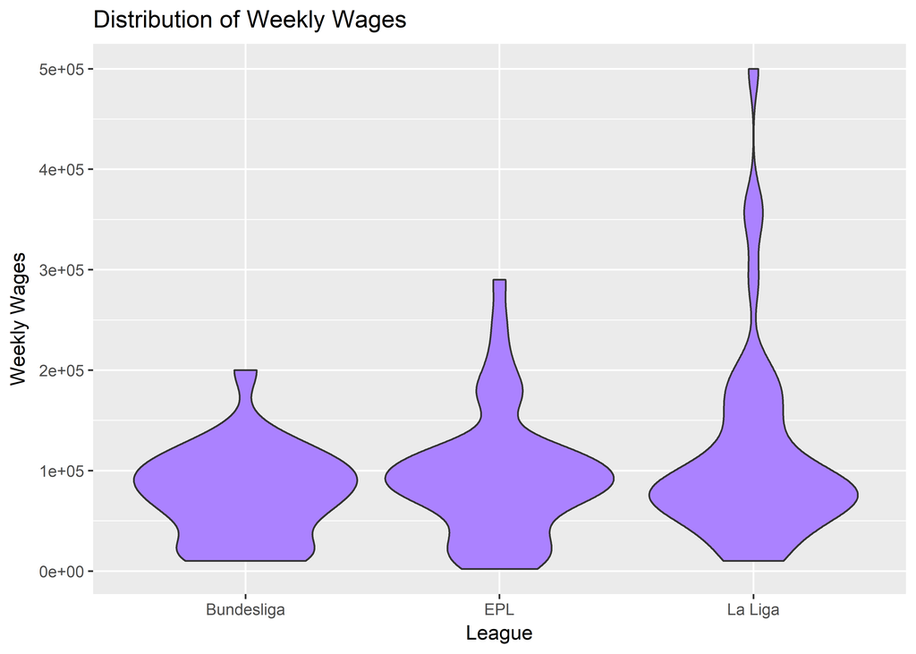

The following model displays weekly wages as a function of age, across all of the top 5 teams.

```
##     age     league weekly_wages model_pred model_resid
## 1    30    La Liga        85000  127425.49 -42425.4920
## 2    30    La Liga        30000  127425.49 -97425.4920
## 3    31    La Liga       200000  135216.94  64783.0629
## 4    24    La Liga       100000   80676.82  19323.1788
## 5    27    La Liga        70000  104051.16 -34051.1566
## 6    29    La Liga       100000  119634.05 -19634.0468
## 7    25    La Liga        85000   88468.27  -3468.2663
## 8    23    La Liga        75000   72885.38   2114.6240
## 9    25    La Liga        90000   88468.27   1531.7337
## 10   27    La Liga       200000  104051.16  95948.8434
## 11   31    La Liga       180000  135216.94  44783.0629
## 12   21    La Liga        20000   57302.49 -37302.4858
## 13   25    La Liga        70000   88468.27 -18468.2663
## 14   21    La Liga        75000   57302.49  17697.5142
```

[output cut: 107 more lines]

```
##
## Call:
## lm_basic(formula = weekly_wages ~ 1 + age, data = wage_age)
##
## Residuals:
##    Min     1Q Median     3Q    Max
## -97425 -40094 -13468  15949 372575
##
## Coefficients:
##             Estimate   2.5 % 97.5 %
## (Intercept)  -106318 -186917 -25718
## age             7791    4765  10818
##
## Residual standard error: 68870 on 119 degrees of freedom
## Multiple R-squared:  0.1792, Adjusted R-squared:  0.1723
## F-statistic: 25.98 on 1 and 119 DF,  p-value: 1.312e-06
```

The output, which includes predictions for the values, is displayed in the scatterplot below, with a trendline as well.

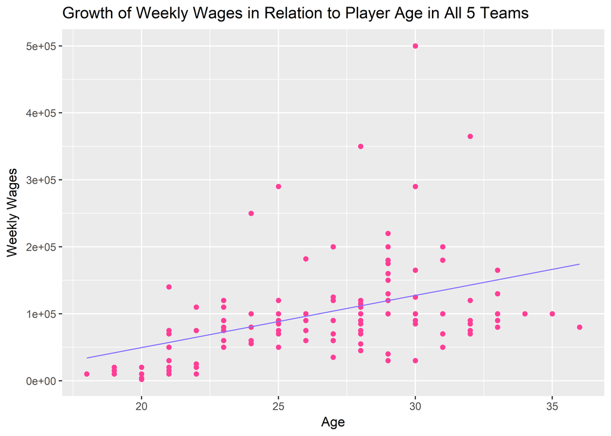

In the model below, the dataset using only the EPL players is used to test if the relationship between weekly wages and age still holds for just Manchester United and Arsenal.

```
##    age league weekly_wages model_pred model_resid
## 1   25    EPL       290000   88028.07 201971.9303
## 2   24    EPL       250000   83786.48 166213.5160
## 3   27    EPL       200000   96511.24 103488.7588
## 4   29    EPL       175000  104994.41  70005.5873
## 5   29    EPL       160000  104994.41  55005.5873
## 6   23    EPL       120000   79544.90  40455.1018
## 7   29    EPL       120000  104994.41  15005.5873
## 8   32    EPL       120000  117719.17   2280.8301
## 9   28    EPL       115000  100752.83  14247.1731
## 10  22    EPL       110000   75303.31  34696.6875
## 11  28    EPL       110000  100752.83   9247.1731
## 12  22    EPL       110000   75303.31  34696.6875
## 13  30    EPL        90000  109236.00 -19235.9984
## 14  32    EPL        85000  117719.17 -32719.1699
```

[output cut: 37 more lines]

```
##
## Call:
## lm_basic(formula = weekly_wages ~ 1 + age, data = epl)
##
## Residuals:
##    Min     1Q Median     3Q    Max
## -64994 -43098 -17270  25989 201972
##
## Coefficients:
##              Estimate     2.5 % 97.5 %
## (Intercept)  -18011.6 -126667.5  90644
## age            4241.6     204.2   8279
##
## Residual standard error: 59750 on 49 degrees of freedom
## Multiple R-squared:  0.08338,    Adjusted R-squared:  0.06467
## F-statistic: 4.457 on 1 and 49 DF,  p-value: 0.03988
```

That relationship is portrayed in the scatterplot below, which also contains a trendline.

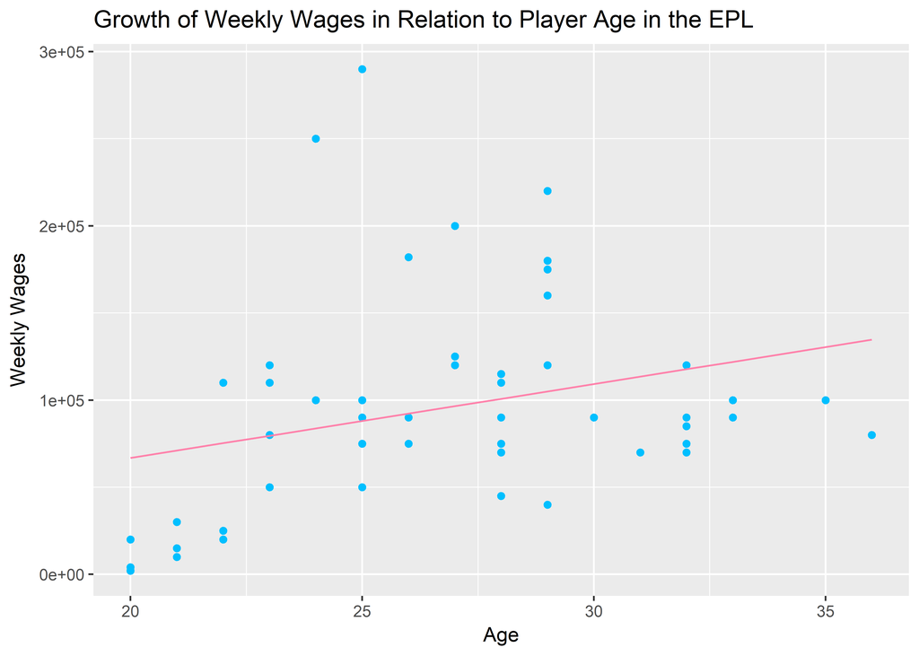

In the following regression model, weekly wages are tested as a function of league, using the dataset that includes players aged 24 and under. The output is displayed in a violin plot below, showing the distribution of each league’s spending on weekly wages for young players.

```
##
## Call:
## lm_basic(formula = weekly_wages ~ 1 + league, data = age_24_under)
##
## Residuals:
##    Min     1Q Median     3Q    Max
## -60706 -39350   1300  23150 187294
##
## Coefficients:
##                  Estimate  2.5 % 97.5 %
## (Intercept)         58700  33056  84344
## leagueBundesliga    -8700 -48125  30725
## leagueEPL            4006 -31177  39189
##
## Residual standard error: 49140 on 40 degrees of freedom
## Multiple R-squared:  0.01113,    Adjusted R-squared:  -0.03831
## F-statistic: 0.2252 on 2 and 40 DF,  p-value: 0.7994
```

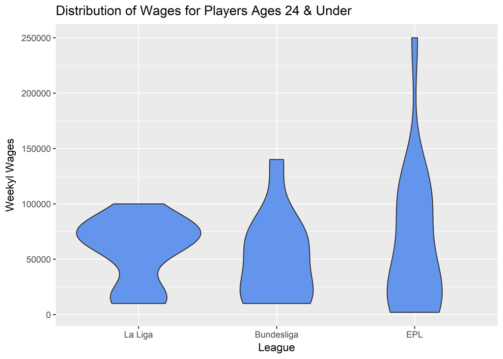

The model below includes weekly wages as a function of age for the Bayern dataset, including predicted values displayed in the scatterplot following the output.

```
##    age     league weekly_wages model_pred model_resid
## 1   31 Bundesliga       100000  105848.53   -5848.532
## 2   29 Bundesliga        30000   95751.13  -65751.128
## 3   25 Bundesliga       120000   75556.32   44443.682
## 4   23 Bundesliga        60000   65458.91   -5458.914
## 5   28 Bundesliga       120000   90702.43   29297.575
## 6   31 Bundesliga        50000  105848.53  -55848.532
## 7   19 Bundesliga        20000   45264.10  -25264.104
## 8   19 Bundesliga        20000   45264.10  -25264.104
## 9   28 Bundesliga       110000   90702.43   19297.575
## 10  28 Bundesliga        85000   90702.43   -5702.425
## 11  21 Bundesliga        70000   55361.51   14638.491
## 12  30 Bundesliga       100000  100799.83    -799.830
## 13  19 Bundesliga        10000   45264.10  -35264.104
## 14  19 Bundesliga        15000   45264.10  -30264.104
## 15  22 Bundesliga        75000   60410.21   14589.789
## 16  34 Bundesliga       100000  120994.64  -20994.639
## 17  33 Bundesliga        80000  115945.94  -35945.937
## 18  26 Bundesliga       100000   80605.02   19394.979
## 19  27 Bundesliga        60000   85653.72  -25653.723
## 20  18 Bundesliga        10000   40215.40  -30215.402
## 21  23 Bundesliga        80000   65458.91   14541.086
## 22  30 Bundesliga       125000  100799.83   24200.170
## 23  21 Bundesliga       140000   55361.51   84638.491
## 24  29 Bundesliga       200000   95751.13  104248.872
## 25  27 Bundesliga        90000   85653.72    4346.277
## 26  21 Bundesliga        50000   55361.51   -5361.509
```

```
##
## Call:
## lm_basic(formula = weekly_wages ~ 1 + age, data = bayern)
##
## Residuals:
##    Min     1Q Median     3Q    Max
## -65751 -25556  -5410  18133 104249
##
## Coefficients:
##             Estimate   2.5 % 97.5 %
## (Intercept)   -50661 -137264  35942
## age             5049    1700   8397
##
## Residual standard error: 39350 on 24 degrees of freedom
## Multiple R-squared:  0.2875, Adjusted R-squared:  0.2578
## F-statistic: 9.684 on 1 and 24 DF,  p-value: 0.004749
```

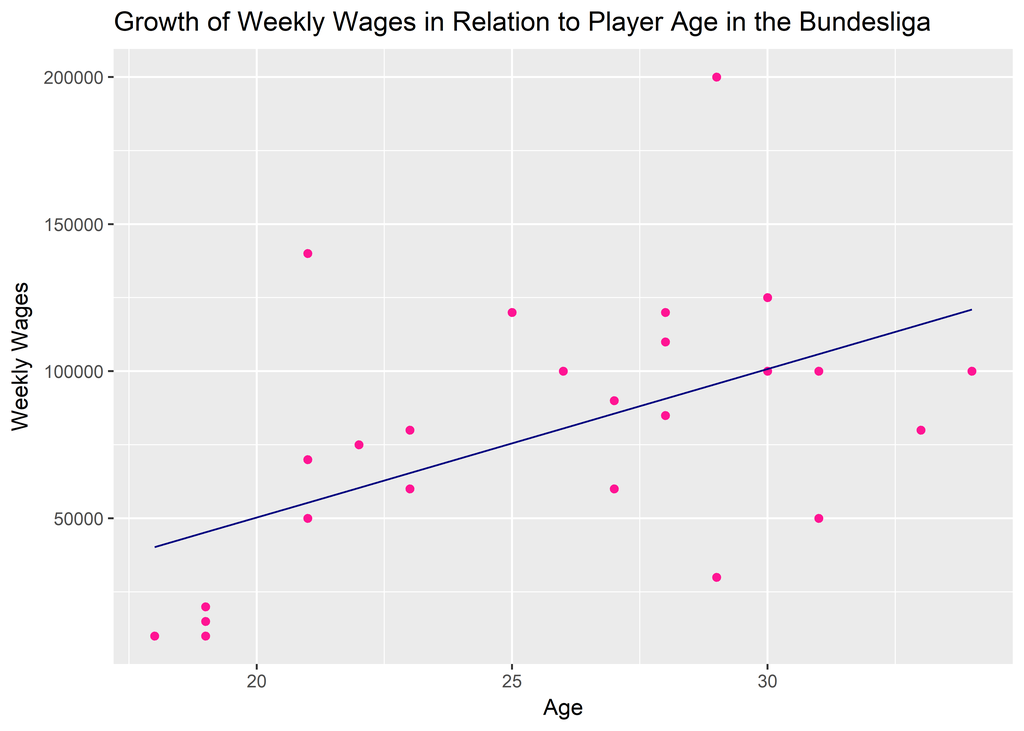

The same model was run for the dataset including only La Liga players, including a scatterplot with fitted values as well.

```
##    age  league weekly_wages model_pred  model_resid
## 1   30 La Liga        85000  171410.88  -86410.8847
## 2   30 La Liga        30000  171410.88 -141410.8847
## 3   31 La Liga       200000  187434.28   12565.7236
## 4   24 La Liga       100000   75270.53   24729.4654
## 5   27 La Liga        70000  123340.71  -53340.7097
## 6   29 La Liga       100000  155387.49  -55387.4930
## 7   25 La Liga        85000   91293.93   -6293.9263
## 8   23 La Liga        75000   59247.14   15752.8571
## 9   25 La Liga        90000   91293.93   -1293.9263
## 10  27 La Liga       200000  123340.71   76659.2903
## 11  31 La Liga       180000  187434.28   -7434.2764
## 12  21 La Liga        20000   27200.36   -7200.3595
## 13  25 La Liga        70000   91293.93  -21293.9263
## 14  21 La Liga        75000   27200.36   47799.6405
```

[output cut: 30 more lines]

```
##
## Call:
## lm_basic(formula = weekly_wages ~ 1 + age, data = laliga)
##
## Residuals:
##     Min      1Q  Median      3Q     Max
## -141411  -41352   -6806   15753  328589
##
## Coefficients:
##             Estimate   2.5 %  97.5 %
## (Intercept)  -309291 -501708 -116874
## age            16023    8830   23217
##
## Residual standard error: 82140 on 42 degrees of freedom
## Multiple R-squared:  0.3248, Adjusted R-squared:  0.3088
## F-statistic: 20.21 on 1 and 42 DF,  p-value: 5.38e-05
```

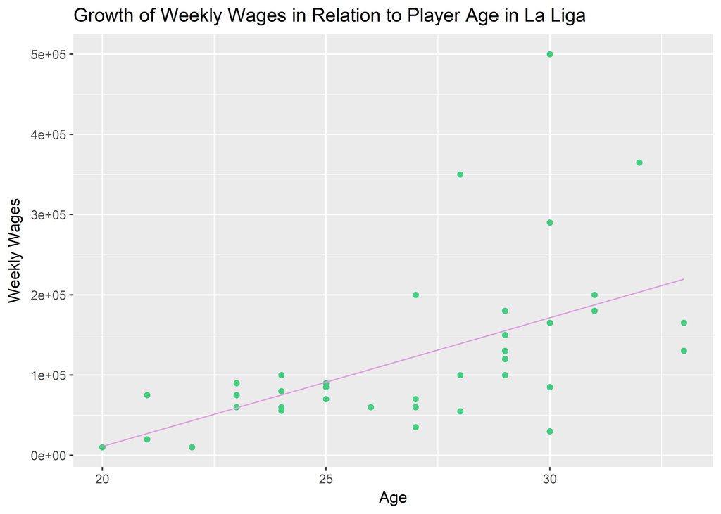

## Conclusions

According to the results of the regression model, Hypothesis 1 positing that age had a significant positive relationship with weekly wages was supported. For every unit increase of age, across all top 5most valuable teams, wages increased by around £7,791. With lower and upper bounds of £4,765 and £10,818, respectively, with a 95% confidence interval, this relationship can be deemed significant. It would not be surprising if the mean were around £4,765 or around £10,818, but either way the relationship between weekly wages and age would still be positive. Furthermore, the latter part of Hypothesis 1, that the singificant relationship between age and weekly wages would remain constant in only the EPL sample of players, was also supported with a slope of around £4,241.6. Ninety-five percent confidence interval bounds were both positive at £204.2 and £8,279, indicating statistical significance. Therefore, as player age increases in the two EPL teams, so too would the players’ wages, by around £4,241.6 with every increase in unit of age.

As shown from the regression model results, Hypothesis 3 was only partially supported. For this hypothesis, I was just observing if the weekly wage growth for the Bundesliga players was less than the other 2 leagues in regards to increasing with age. The Bundesliga’s slope was around £5,049 (significant positive relationship, indicating weekly wage growth of around £5,049 for every year in age gained by each player), which was indeed less than La Liga’s growth of around £16,023, but the EPL displayed less slope growth than the Bundesliga with a slope of around £4,241.6. It is important to note that La Liga has a few outlying players in their 2017/18 wage table. Cristiano Ronaldo’s weekly wages are £365,000 and Gareth Bale’s are £350,000, and Lionel Messi’s weekly wages are £500,000, all of which probably skew La Liga’s mean upwards. Furthermore, Arsenal have two players who’s weekly wages are £2,000 and £4,000, both of which could be outliers that drag down the EPL’s mean.

These results cannot be generalized to the entirety of the EPL, La Liga, or the Bundesliga, seeing as there were only 2 teams used from the EPL and La Liga and only 1 team used from the Bundesliga. However, it is nonetheless interesting to compare the spending of each of the clubs on their players.

## References

https://www.totalsportek.com/money/real-madrid-player-salaries/ http://www.spotrac.com/epl/manchester-united-f.c/payroll/ https://www.totalsportek.com/money/barcelona-player-salaries/ http://tsmsportz.com/football/bayern-munich-players-salaries/ http://www.spotrac.com/epl/arsenal-f.c/payroll/ https://www.si.com/planet-futbol/photo/2017/03/31/most-valuable-soccer-clubs-top-10-real-madrid-manchester-united-barcelona http://www.dw.com/en/the-top-10-most-expensive-football-transfers/g-41958100 https://en.wikipedia.org/wiki/List_of_European_Cup_and_UEFA_Champions_League_finals#By_club